# Lecture 3 - 9-11

# Notes about formatting Markdown files

There are three major components to this file: *1) YAML header: The segment at the beginning of the document bracketed by —s.* 2) Text + inline R: Written text with simple formatting like # heading, **bold**, and *italic* (enter inline code by typing ‘`r`’ + ‘format()’ ) *3) Code chunks: Blocks of code surrounded by ``` (enter by pressing option+command+I) and name the code chunks {r chunk_name}.* 4) ‘knitr’ = knitting, which combines text, formatting, and code

# create a dataframe containing a sample of size 500 from a random normal variable and the absolute value of each element of the sample

```r
library(tidyverse)
```

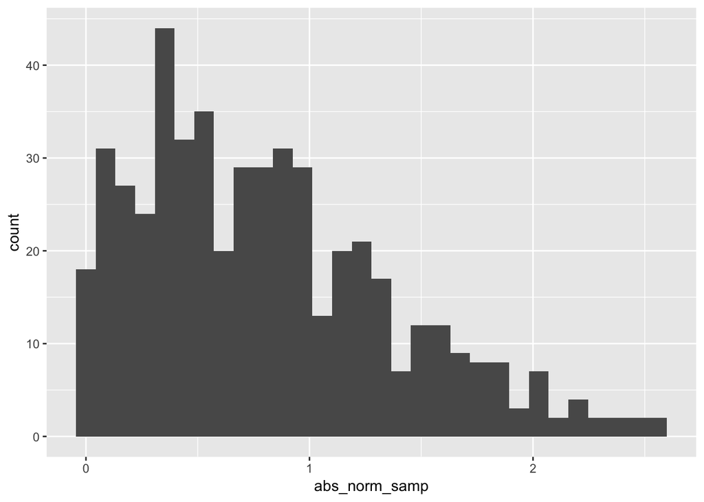

```r
ls_df = tibble(
  norm_samp = rnorm(500),
  abs_norm_samp = abs(norm_samp)
)

ggplot(ls_df, aes(x = abs_norm_samp)) + geom_histogram () # make a histogram of the absolute value of each element in the sample
```

```r
round(median(ls_df$abs_norm_samp), digits=2) #median of the variable containing absolute values rounded to 2 decimal places is
```

```
## [1] 0.71
```

# to customize code chunk formatting

*eval = FALSE: code will be displayed but not executed; results are not included.* echo = FALSE: code will be executed but not displayed; results are included. *include = FALSE: code will be executed but not displayed; results are not included.* message = FALSE and warning = FALSE: prevents messages and warnings from being displayed. *results = hide and fig.show = hide: prevents results and figures from being shown, respectively.* collapse = TRUE: output will be collapsed into a single block at shown at the end of the chunk.

*error: errors in code will stop rendering when FALSE; errors in code will be printed in the doc when TRUE. The default is FALSE and you should almost never change it.

# Find mean and median

```r
mean(ls_df$norm_samp)
```

```
## [1] -0.01770162
```

```r
median(ls_df$norm_samp)
```

```
## [1] -0.0223511
```

# to create diff types of document

html_document:  
toc: true toc_float: true

output:  
word_document: default

output:  
pdf_document: default